# Project: Red Wine Quality Analysis by Mohammad Yaqoob

People looks for good bottle of wine at every price point. We all have different measure of quality of wine and we all have different view of “expensive wine is better” spectrum. Business Insider states “What does good mean, though? It’s a completely subjective measure . unless you ask a professional.” Wine enjoyment is such an objective experience and taste is not exactly an exact science. Drinking wine can be an especially psychologically driven experience, influenced by numerous factors: labels, price points, bottle appearance, and even our peers, just to name a few. In this project, I chose Red Wine dataset which contains list of wines, their expert quality ratings, and their ingredients to study if any of the ingredients effect quality of the wine and how? I also want to see there is a way to qulity prediction using the data without taste test. The data is available for download from https://www.google.com/url?q=https%3A%2F%2Fs3.amazonaws.com%2Fudacity-hosted-downloads%2Fud651%2FwineQualityReds.csv&sa=D&sntz=1&usg=AFQjCNFbtvciXJWwSbQuwE2Br_pH9JquAg.

### Summary of the Data set

```
##  [1] "X"                    "fixed.acidity"        "volatile.acidity"
##  [4] "citric.acid"          "residual.sugar"       "chlorides"
##  [7] "free.sulfur.dioxide"  "total.sulfur.dioxide" "density"
## [10] "pH"                   "sulphates"            "alcohol"
## [13] "quality"
```

```
##        X        fixed.acidity   volatile.acidity  citric.acid
##  Min.   :   1   Min.   : 4.60   Min.   :0.120    Min.   :0.000
##  1st Qu.: 400   1st Qu.: 7.10   1st Qu.:0.390    1st Qu.:0.090
##  Median : 800   Median : 7.90   Median :0.520    Median :0.260
##  Mean   : 800   Mean   : 8.32   Mean   :0.528    Mean   :0.271
##  3rd Qu.:1200   3rd Qu.: 9.20   3rd Qu.:0.640    3rd Qu.:0.420
##  Max.   :1599   Max.   :15.90   Max.   :1.580    Max.   :1.000
##  residual.sugar    chlorides      free.sulfur.dioxide total.sulfur.dioxide
##  Min.   : 0.90   Min.   :0.0120   Min.   : 1.0        Min.   :  6.0
##  1st Qu.: 1.90   1st Qu.:0.0700   1st Qu.: 7.0        1st Qu.: 22.0
##  Median : 2.20   Median :0.0790   Median :14.0        Median : 38.0
##  Mean   : 2.54   Mean   :0.0875   Mean   :15.9        Mean   : 46.5
##  3rd Qu.: 2.60   3rd Qu.:0.0900   3rd Qu.:21.0        3rd Qu.: 62.0
##  Max.   :15.50   Max.   :0.6110   Max.   :72.0        Max.   :289.0
##     density            pH         sulphates        alcohol
##  Min.   :0.990   Min.   :2.74   Min.   :0.330   Min.   : 8.4
##  1st Qu.:0.996   1st Qu.:3.21   1st Qu.:0.550   1st Qu.: 9.5
##  Median :0.997   Median :3.31   Median :0.620   Median :10.2
##  Mean   :0.997   Mean   :3.31   Mean   :0.658   Mean   :10.4
##  3rd Qu.:0.998   3rd Qu.:3.40   3rd Qu.:0.730   3rd Qu.:11.1
##  Max.   :1.004   Max.   :4.01   Max.   :2.000   Max.   :14.9
##     quality
##  Min.   :3.00
##  1st Qu.:5.00
##  Median :6.00
##  Mean   :5.64
##  3rd Qu.:6.00
##  Max.   :8.00
```

```
## 'data.frame':    1599 obs. of  13 variables:
##  $ X                   : int  1 2 3 4 5 6 7 8 9 10 ...
##  $ fixed.acidity       : num  7.4 7.8 7.8 11.2 7.4 7.4 7.9 7.3 7.8 7.5 ...
##  $ volatile.acidity    : num  0.7 0.88 0.76 0.28 0.7 0.66 0.6 0.65 0.58 0.5 ...
##  $ citric.acid         : num  0 0 0.04 0.56 0 0 0.06 0 0.02 0.36 ...
##  $ residual.sugar      : num  1.9 2.6 2.3 1.9 1.9 1.8 1.6 1.2 2 6.1 ...
##  $ chlorides           : num  0.076 0.098 0.092 0.075 0.076 0.075 0.069 0.065 0.073 0.071 ...
##  $ free.sulfur.dioxide : num  11 25 15 17 11 13 15 15 9 17 ...
##  $ total.sulfur.dioxide: num  34 67 54 60 34 40 59 21 18 102 ...
##  $ density             : num  0.998 0.997 0.997 0.998 0.998 ...
##  $ pH                  : num  3.51 3.2 3.26 3.16 3.51 3.51 3.3 3.39 3.36 3.35 ...
##  $ sulphates           : num  0.56 0.68 0.65 0.58 0.56 0.56 0.46 0.47 0.57 0.8 ...
##  $ alcohol             : num  9.4 9.8 9.8 9.8 9.4 9.4 9.4 10 9.5 10.5 ...
##  $ quality             : int  5 5 5 6 5 5 5 7 7 5 ...
```

# Univariate Plots Section

### Density plots for each variable

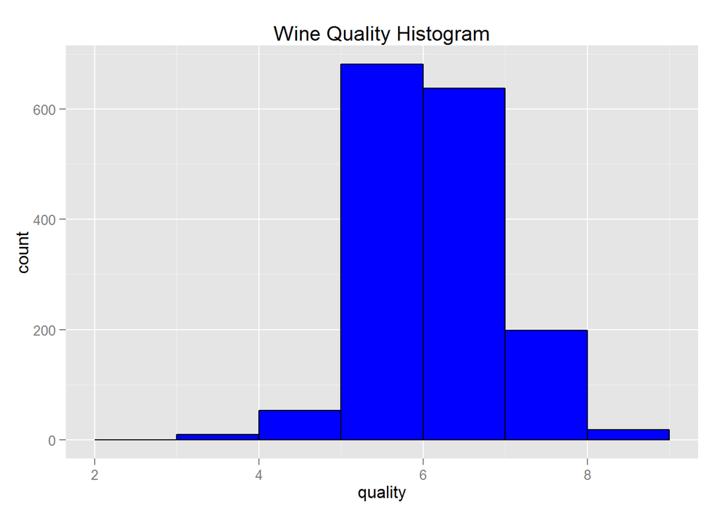

```
##    Min. 1st Qu.  Median    Mean 3rd Qu.    Max.
##    3.00    5.00    6.00    5.64    6.00    8.00
## [1] 5.636
## [1] 0.8076
## 10% 50% 90%
##   5   6   7
```

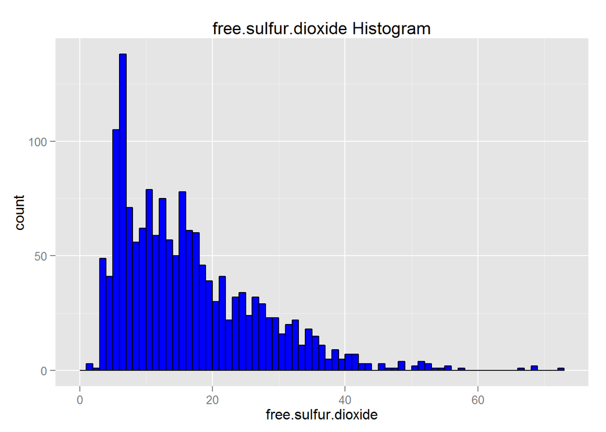

```
##    Min. 1st Qu.  Median    Mean 3rd Qu.    Max.
##     1.0     7.0    14.0    15.9    21.0    72.0
## [1] 15.87
## [1] 10.46
## 10% 50% 90%
##   5  14  31
```

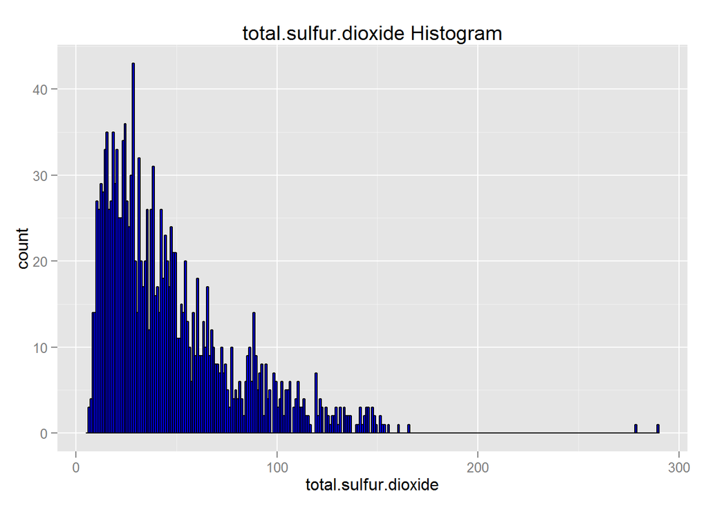

```
##    Min. 1st Qu.  Median    Mean 3rd Qu.    Max.
##     6.0    22.0    38.0    46.5    62.0   289.0
## [1] 46.47
## [1] 32.9
##  10%  50%  90%
## 14.0 38.0 93.2
```

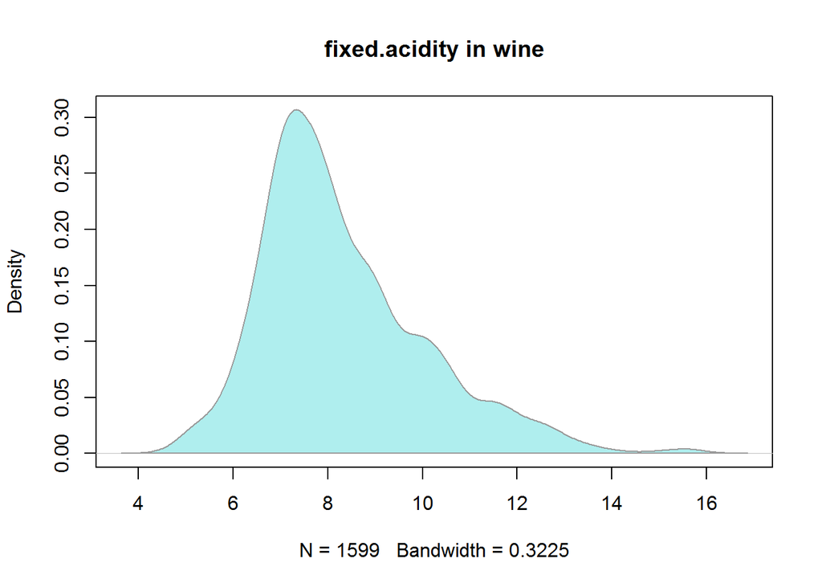

```
##    Min. 1st Qu.  Median    Mean 3rd Qu.    Max.
##    4.60    7.10    7.90    8.32    9.20   15.90
## [1] 8.32
## [1] 1.741
##  10%  50%  90%
##  6.5  7.9 10.7
```

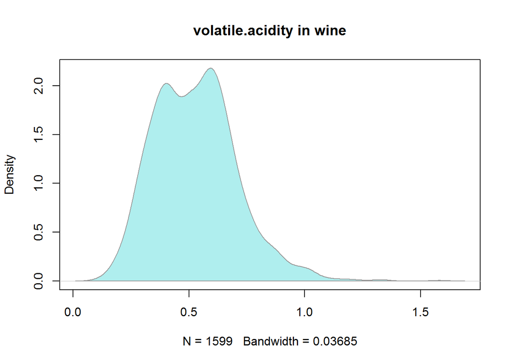

```
##    Min. 1st Qu.  Median    Mean 3rd Qu.    Max.
##   0.120   0.390   0.520   0.528   0.640   1.580
## [1] 0.5278
## [1] 0.1791
##   10%   50%   90%
## 0.310 0.520 0.745
```

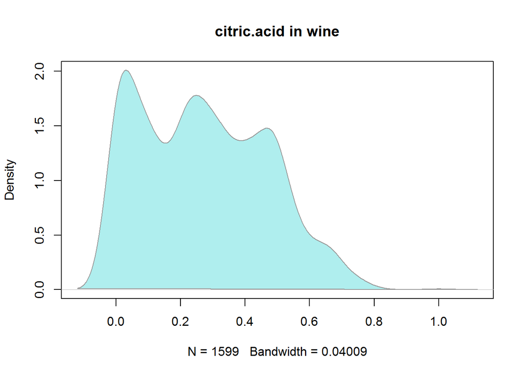

```
##    Min. 1st Qu.  Median    Mean 3rd Qu.    Max.
##   0.000   0.090   0.260   0.271   0.420   1.000
## [1] 0.271
## [1] 0.1948
##   10%   50%   90%
## 0.010 0.260 0.522
```

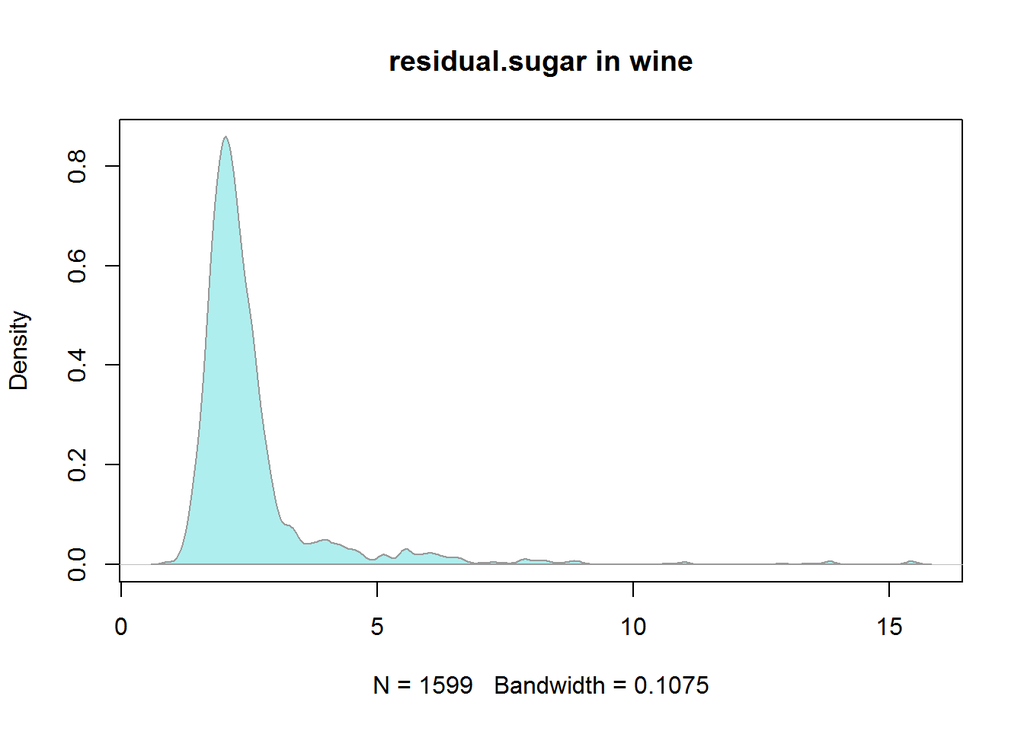

```
##    Min. 1st Qu.  Median    Mean 3rd Qu.    Max.
##    0.90    1.90    2.20    2.54    2.60   15.50
## [1] 2.539
## [1] 1.41
## 10% 50% 90%
## 1.7 2.2 3.6
```

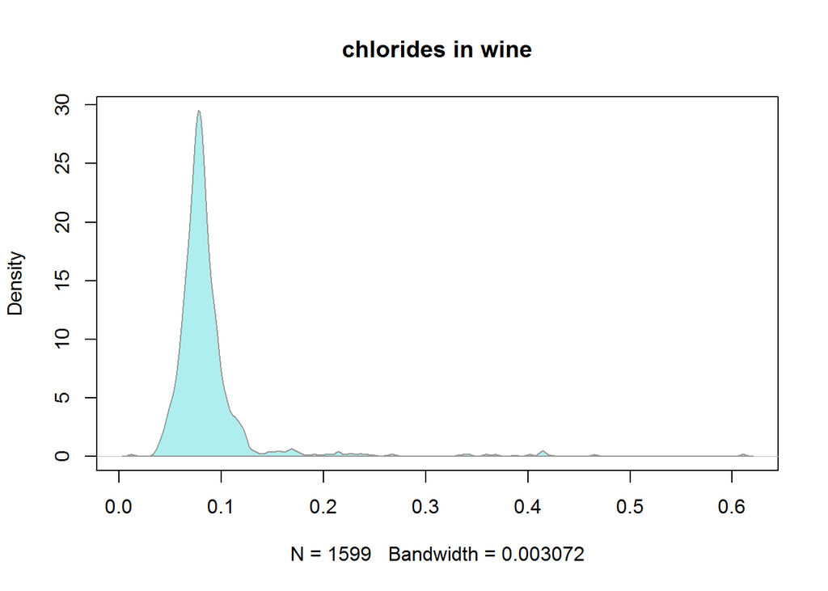

```
##    Min. 1st Qu.  Median    Mean 3rd Qu.    Max.
##  0.0120  0.0700  0.0790  0.0875  0.0900  0.6110
## [1] 0.08747
## [1] 0.04707
##   10%   50%   90%
## 0.060 0.079 0.109
```

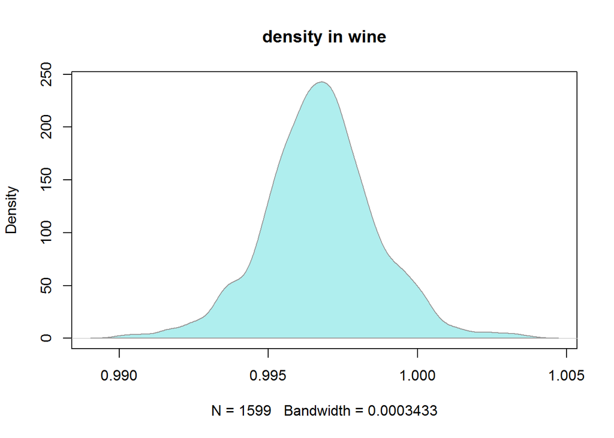

```
##    Min. 1st Qu.  Median    Mean 3rd Qu.    Max.
##   0.990   0.996   0.997   0.997   0.998   1.000
## [1] 0.9967
## [1] 0.001887
##    10%    50%    90%
## 0.9946 0.9968 0.9991
```

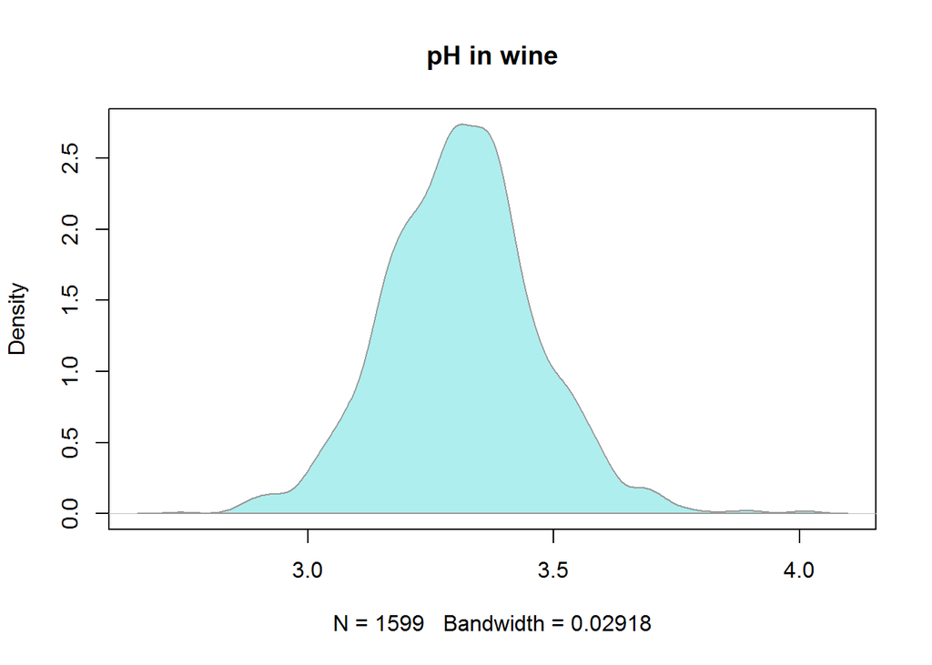

```
##    Min. 1st Qu.  Median    Mean 3rd Qu.    Max.
##    2.74    3.21    3.31    3.31    3.40    4.01
## [1] 3.311
## [1] 0.1544
##  10%  50%  90%
## 3.12 3.31 3.51
```

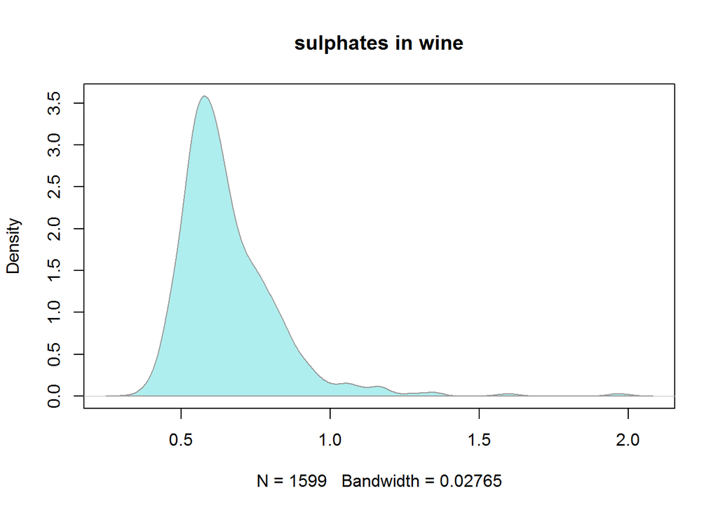

```
##    Min. 1st Qu.  Median    Mean 3rd Qu.    Max.
##   0.330   0.550   0.620   0.658   0.730   2.000
## [1] 0.6581
## [1] 0.1695
##  10%  50%  90%
## 0.50 0.62 0.85
```

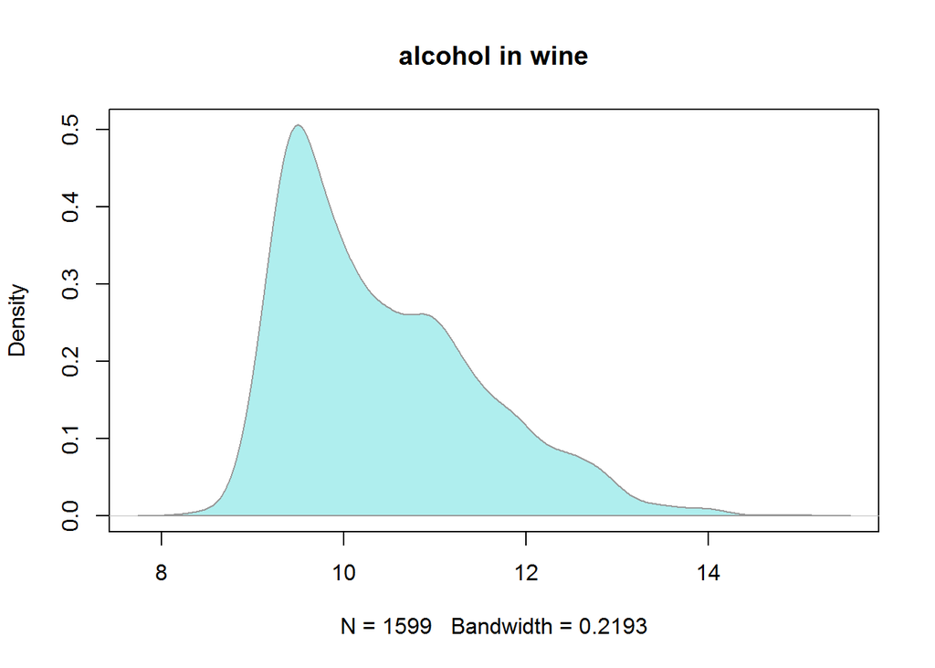

```
##    Min. 1st Qu.  Median    Mean 3rd Qu.    Max.
##     8.4     9.5    10.2    10.4    11.1    14.9
## [1] 10.42
## [1] 1.066
##  10%  50%  90%
##  9.3 10.2 12.0
```

# Univariate Analysis

### What is/are the main feature(s) of interest in your dataset?

My main interest in the dataset will be quality as I would like see if I can accurately predict quality of the wine using other variable or combination of varibales. It is clear that most of the wine evaluation are 5 or 6 while the minimum quality is 3 and maximum 8. The mean falls right between 5 and 6 at 5.636.

### What other features in the dataset do you think will help support your investigation into your feature(s) of interest?

Beer, Margritas, Bloody Mary, and all types of drinks involve alcohol, I suppose it may have an impact on the qulity on the of wine. Hence, I would like to add this to the features to be investiagted. Winefolly.com states “Alcohol adds body”, hence it is appropriate to investigate this feature. Winefolly.com and other sites also suggests Citrix acid to have impact as well. Reviewing the description of the variables for the dataset and reading about wine quality on the internet it seems some of these are really important in identifying the quality of the wine.

Some of those variables are:

- Volatile Acidity : Can lead to vinegar taste in high quantity (Variable description). Acidity in food and drink is tart and zesty (Winfolly.com)
- Residual Sugar : Determines the sweetness of a wine (Varibale description). Often, the very first impression of a wine is its level of sweetness (Winefolly.com)
- Free Sulfur Dioxide : Seems to become evident after a certain amount (variable description). Sulfur dioxide has also a positive effect on wine flavors and aromas (diwinetaste.com)
- Sulphates : Acts as an antimicrobial and antioxidant (Varibale description). … used in enology for its important antioxidant, preservative and antiseptic properties (diwinetaste.com)

### Did you create any new variables from existing variables in the dataset?

I did not created any new variables from existing variables in the dataset.

### Of the features you investigated, were there any unusual distributions? Did you perform any operations on the data to tidy, adjust, or change the form of the data? If so, why did you do this?

Most of the distribution were normal either left or right skewed. The unusual ones were Citrix acid trimodial and volatile.acidity bimodial distribution. Alcohol distribution was unsual as one would expect it to me either normal or evenly distributed, but it was positively skewed with a peak around 9/10. All data was readily available and I no transformation was needed as dataset was already tidy.

# Bivariate Plots Section

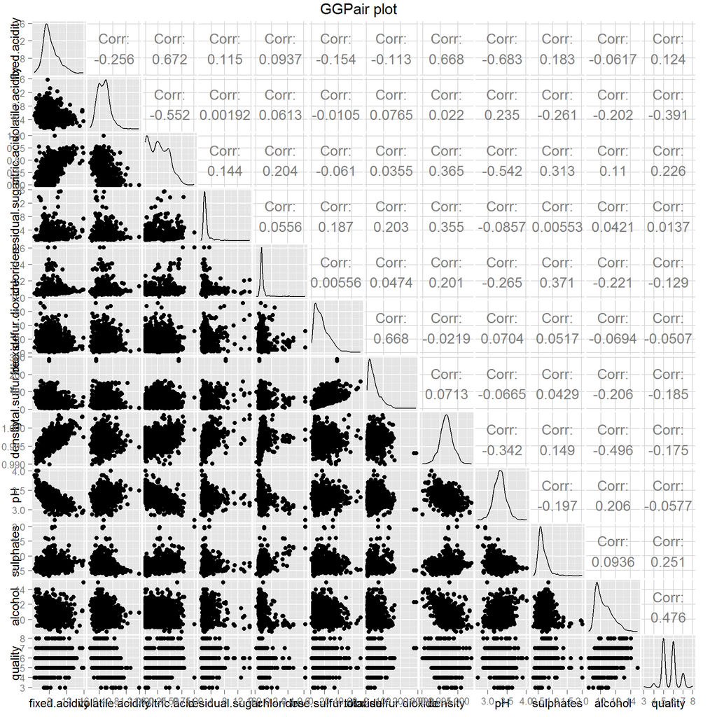

From the ggpair graph I will check for the most correlated variables with quality. The graph shows the following variables have the most correlation with quality.

- Alcohol
- Voltile Acidity
- Sulphates
- Citrix Acid

I will dig deeper into these variables to find out the relationship between these variables and the outcome variable quality and how significant the relationship is?

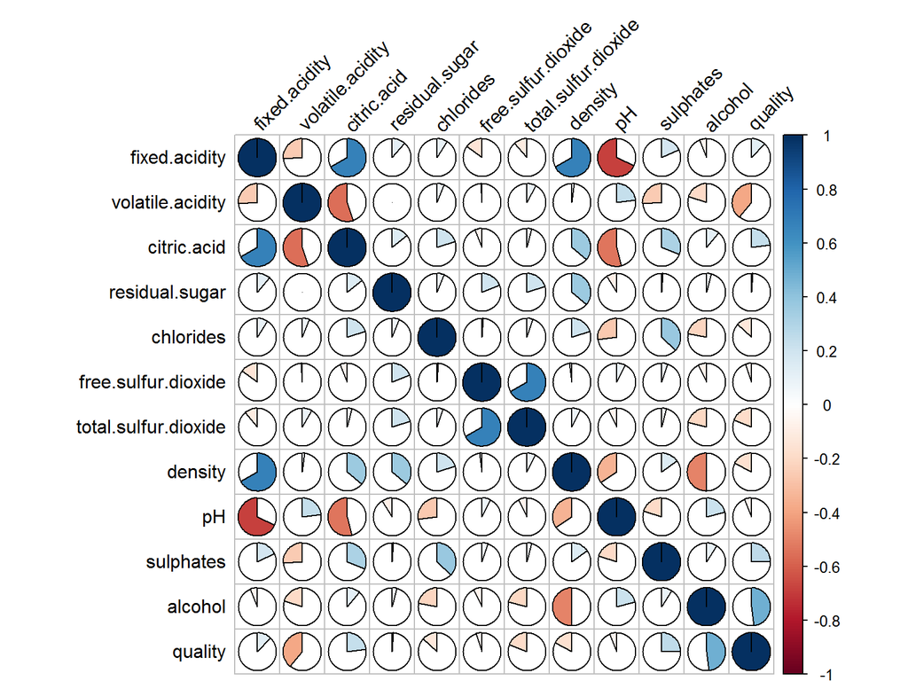

The above chart is of correlation matrix with each square representing the calculated value of the correlation coefficient between the 2 intersecting variables. th scale is measured from 1 to -1 colored from dark blue to dark red respectively. In this chart:

- The size of the pie indicates the correlation significnce
- Blue color inidicate Positive correlation
- Red color indicates the Negative correlation

From chart I can see that the strong correlations to quality are with variables:

- alcohol
- sulphates
- volatile.acidity
- citric.acid

I also observered even stronger correlation between the following variables:

- pH/fixed.acidity
- citric.acid/fixed.acidity
- total.sulfur.dioxide/free.sulfur.dioxide

These above correlations I saw in the charts these have nothing to do with quality, they are between between these variables and I don’t think these correlations have any meaningful impact on the quality of the wine.

Next lets dig deeper and compute P-Values and check actual correlation values to validate my above findings.

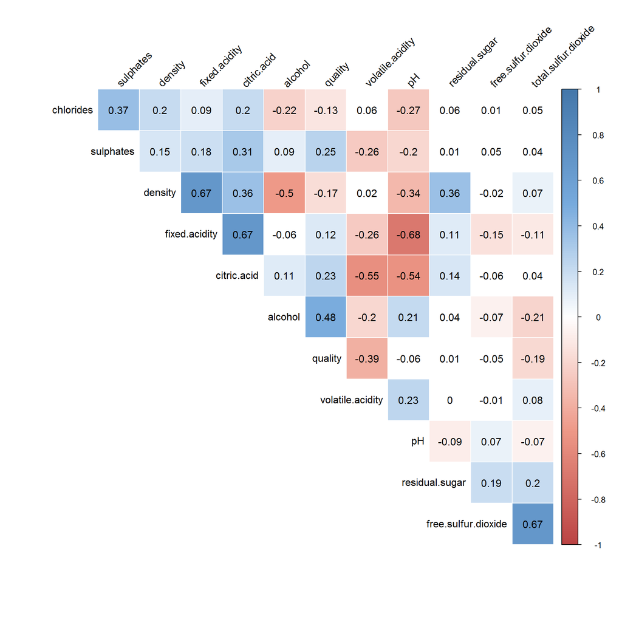

The above charts confirms my finding about varibales alcohol, sulphates, volatile.acidity and citric.acid and their correlation to quality.

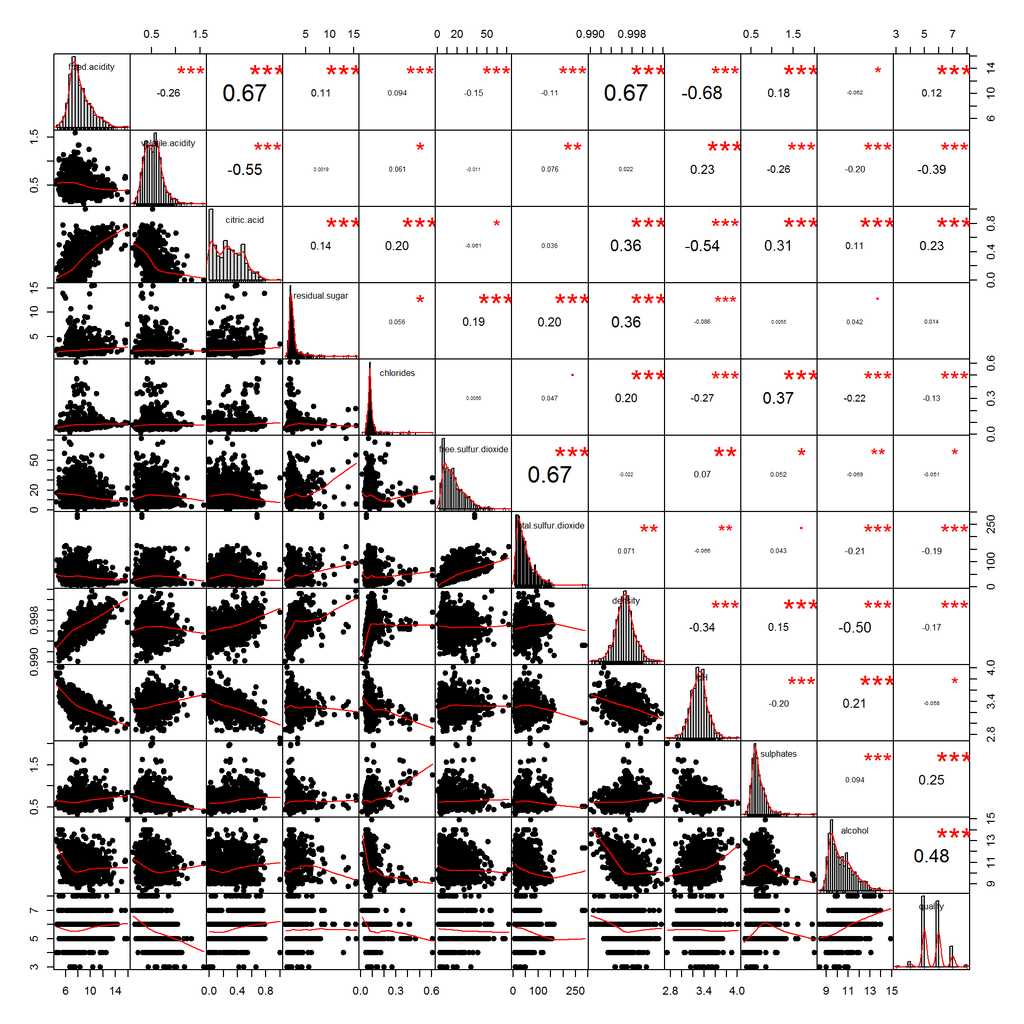

In the above Chart:

- The distribution of each variable is shown on the diagonal.
- On the bottom of the diagonal : the bivariate scatter plots with a fitted line are displayed
- On the top of the diagonal : the value of the correlation plus the significance level as stars
- Each significance level is associated to a symbol : p-values(0, 0.001, 0.01, 0.05, 0.1, 1) <=> symbols(“3-stars”, “2-stars”, “star”, “dot”, “blank”)

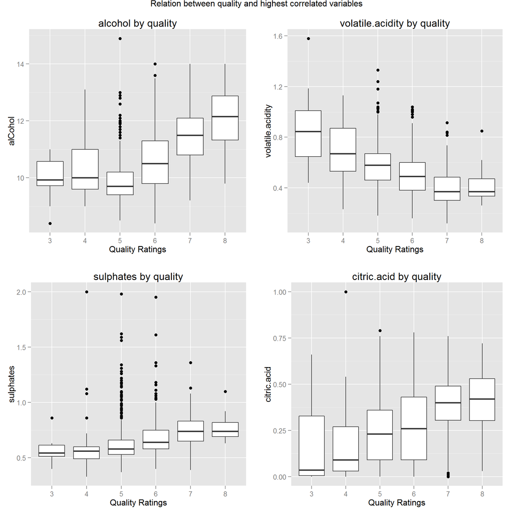

The boxplots shows:

- The mean values alcohol percentage in relation to quality increase as the quality goes up. The worst wines average about 10% alcohol while the best average just above 12% alcohol.
- The mean values of volatile.acidity tend to decrease as the quality goes up. The best wines come in at about .4 while the worst wines reach about .8.
- As the quality of wine increases, the so do the sulphates.
- The mean value of citric acid tends to increase as the quality goes up. Citrix acid appears to increase in sets of bad wine (3-4), average wine (5,6) and good wine (7,8).

Hence I will use the above variables when I build my model since the above graphs show they are the most likely candidates for the my model.

# Bivariate Analysis

### Talk about some of the relationships you observed in this part of the investigation. How did the feature(s) of interest vary with other features in the dataset?

The graphs above shows all the varibales and their correlation to quality and to each other. What I have found is that quality didn’t actually has the strongest associations in the list maybe that is due size of the dataset. What is obvious from above graphs is what I expected that the stronger correlations existed between the related varibales e.g. pH, fixed acidity, and citric.acid as well as free.sulfur.dioxide and total.sulfur.dioxide.  
The following correlations are considered important with respect to quality:

- Alcohol : 0.48 ==> Postive correlation to quality
- Sulphates : 0.25 ==> Positive correlation to quality
- Citric Acid: 0.23 ==> Positive correlation to quality
- Volatile Acidity : -0.39 ==> Negative correlation to quality

After Reading many articles about wine quality, I see why I got variables as above most related to wine quality. Alcohol, sulphates, citric acid, and volatile acidity are particularly sensitive to changing the quality of a wine more than the other variables do.

### Did you observe any interesting relationships between the other features (not the main feature(s) of interest)?

The most interesting relationship is between variable density and other variables. I am not sure what makes up density hence I can’t figure out why density has high correlation to other variables. My assumption is that probably most of these variables are some way or another are related to density.

### What was the strongest relationship you found?

The strongest relationship I found is between pH and fixed.acidity at -0.68. Free.sulfur.dioxide and total.sulfur.dioxide came in at a close 2nd with 0.67. The strongest relationship to quality was alcohol at 0.48.

# Multivariate Plots Section

Here we will explore the relationship between variables and the outcome quality. Before jumping into a regression analysis, we can use a Principal Components (multivariate) Analysis to detect collinearity or correlation among the variables. Identifying variables that are highly collinear-which can make one of the variables almost redundant in some cases-can help us select the best logistic regression model.

```
## **Results for the Principal Component Analysis (PCA)**
## The analysis was performed on 1599 individuals, described by 12 variables
## *The results are available in the following objects:
##
##    name               description
## 1  "$eig"             "eigenvalues"
## 2  "$var"             "results for the variables"
## 3  "$var$coord"       "coord. for the variables"
## 4  "$var$cor"         "correlations variables - dimensions"
## 5  "$var$cos2"        "cos2 for the variables"
## 6  "$var$contrib"     "contributions of the variables"
## 7  "$ind"             "results for the individuals"
## 8  "$ind$coord"       "coord. for the individuals"
## 9  "$ind$cos2"        "cos2 for the individuals"
## 10 "$ind$contrib"     "contributions of the individuals"
## 11 "$call"            "summary statistics"
## 12 "$call$centre"     "mean of the variables"
## 13 "$call$ecart.type" "standard error of the variables"
## 14 "$call$row.w"      "weights for the individuals"
## 15 "$call$col.w"      "weights for the variables"
```

```
##        eigenvalue percentage of variance
## comp 1     3.1212                 26.010
## comp 2     2.2419                 18.682
## comp 3     1.6829                 14.024
## comp 4     1.2150                 10.125
## comp 5     0.9733                  8.111
## comp 6     0.6626                  5.522
```

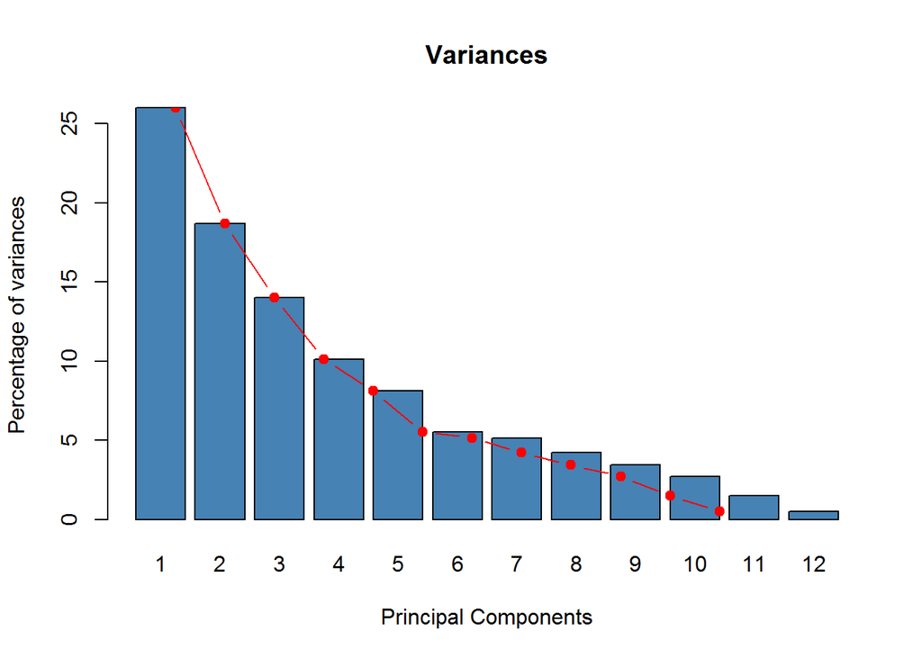

The above chart shows approximately 68% of variability is addressed but the first 4 components.

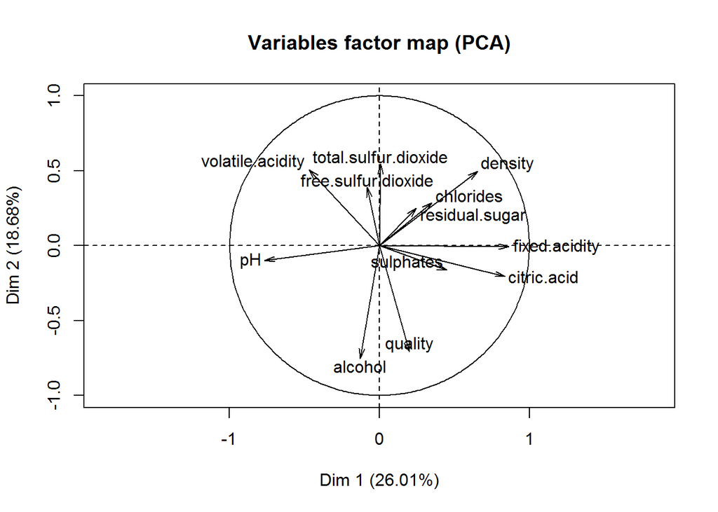

Because of these strong collinearities, different models (that include different variables) may be equally acceptable in terms of prediction. This needs to be considered once a final model has been selected.

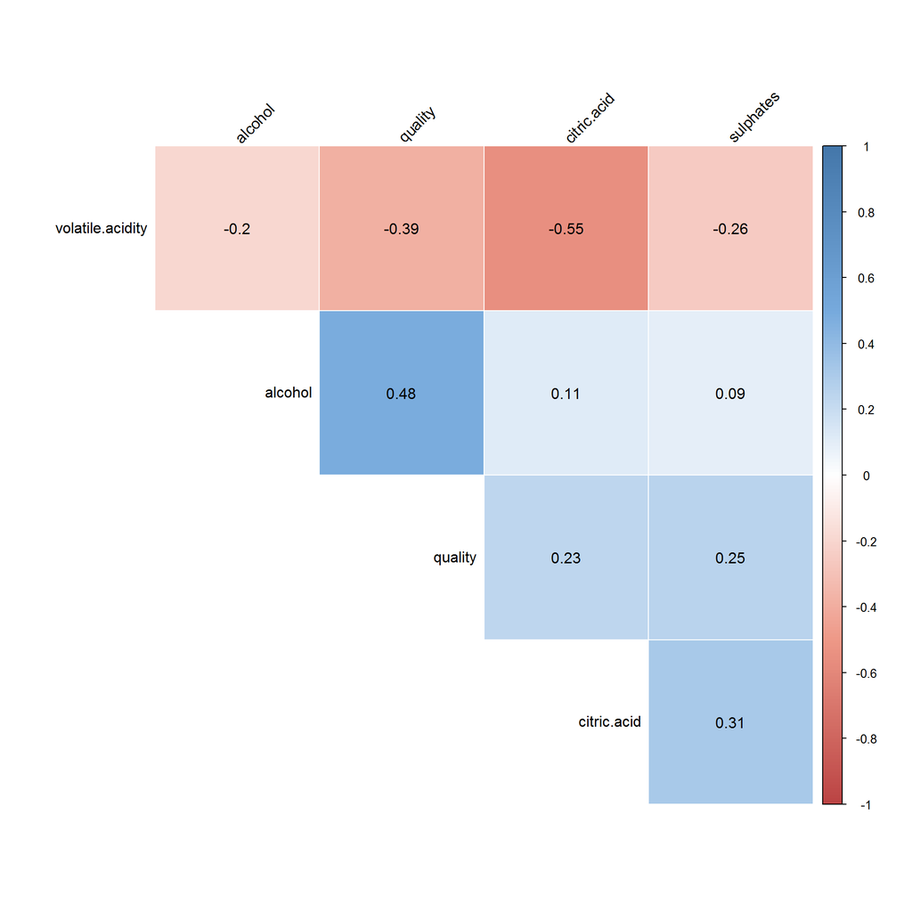

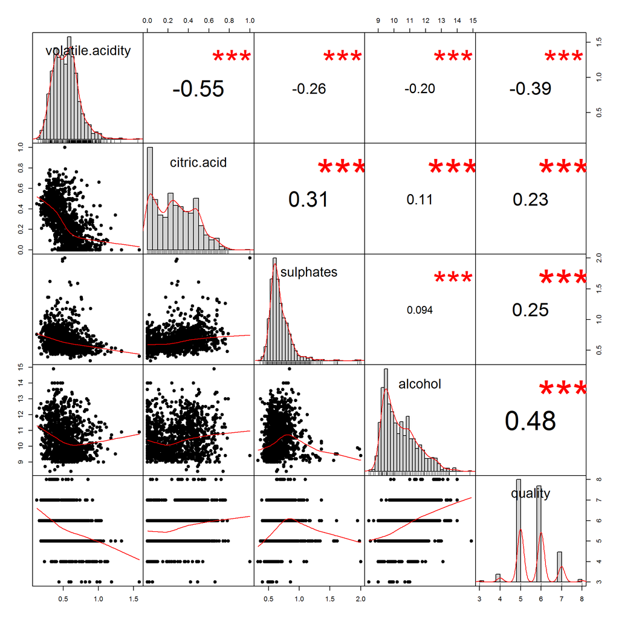

Correlation chart of our selected variables above shows the relationship to outcome quality. Next setup model and investigate

```
##
## Call:
## lm(formula = quality ~ alcohol + volatile.acidity + citric.acid +
##     sulphates, data = RedWines)
##
## Residuals:
##    Min     1Q Median     3Q    Max
## -2.714 -0.386 -0.064  0.467  2.204
##
## Coefficients:
##                  Estimate Std. Error t value Pr(>|t|)
## (Intercept)        2.6459     0.2011   13.16  < 2e-16 ***
## alcohol            0.3091     0.0158   19.55  < 2e-16 ***
## volatile.acidity  -1.2651     0.1127  -11.23  < 2e-16 ***
## citric.acid       -0.0791     0.1038   -0.76     0.45
## sulphates          0.6955     0.1031    6.75  2.1e-11 ***
## ---
## Signif. codes:  0 '***' 0.001 '**' 0.01 '*' 0.05 '.' 0.1 ' ' 1
##
## Residual standard error: 0.659 on 1594 degrees of freedom
## Multiple R-squared:  0.336,  Adjusted R-squared:  0.334
## F-statistic:  202 on 4 and 1594 DF,  p-value: <2e-16
```

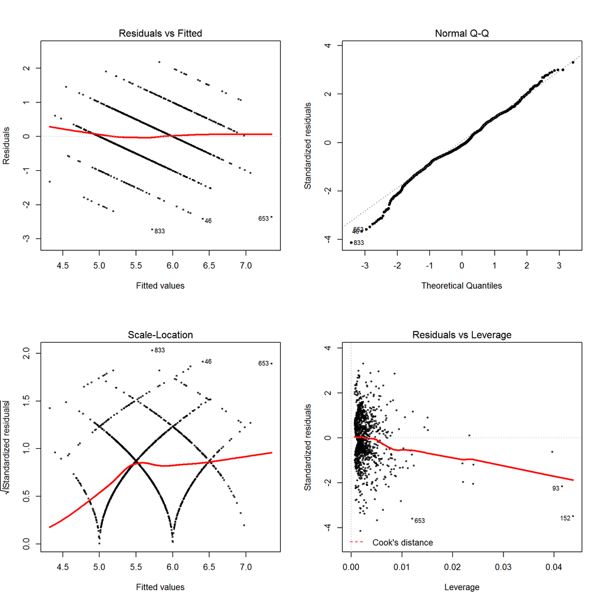

```
##
## Call:
## lm(formula = quality ~ alcohol + volatile.acidity + sulphates,
##     data = RedWines)
##
## Residuals:
##     Min      1Q  Median      3Q     Max
## -2.7186 -0.3820 -0.0641  0.4745  2.1807
##
## Coefficients:
##                  Estimate Std. Error t value Pr(>|t|)
## (Intercept)        2.6108     0.1957   13.34  < 2e-16 ***
## alcohol            0.3092     0.0158   19.57  < 2e-16 ***
## volatile.acidity  -1.2214     0.0970  -12.59  < 2e-16 ***
## sulphates          0.6790     0.1008    6.74  2.3e-11 ***
## ---
## Signif. codes:  0 '***' 0.001 '**' 0.01 '*' 0.05 '.' 0.1 ' ' 1
##
## Residual standard error: 0.659 on 1595 degrees of freedom
## Multiple R-squared:  0.336,  Adjusted R-squared:  0.335
## F-statistic:  269 on 3 and 1595 DF,  p-value: <2e-16
```

- Residuals vs Fitted - Generally horizontal trend line with a generally random variation a points surrounding it. This indicates that the distribution is most likely unbiased.
- Normal QQ - The theoretical quantiles generally follow the standardized residuals idicating that the errors of model are approximately normally distributed and approximately good model fit.
- Scale-Location - Variation of the Residuals vs Fitted plot that uses the square root of the standardized residuals instead of the residuals indicating that the distribution of residuals is most likely unbiased.
- Residuals vs Leverage - Not major pulling points in the model with fewer points beyond 0.010. One point appears to have a drastic effect on the outcome of the model.

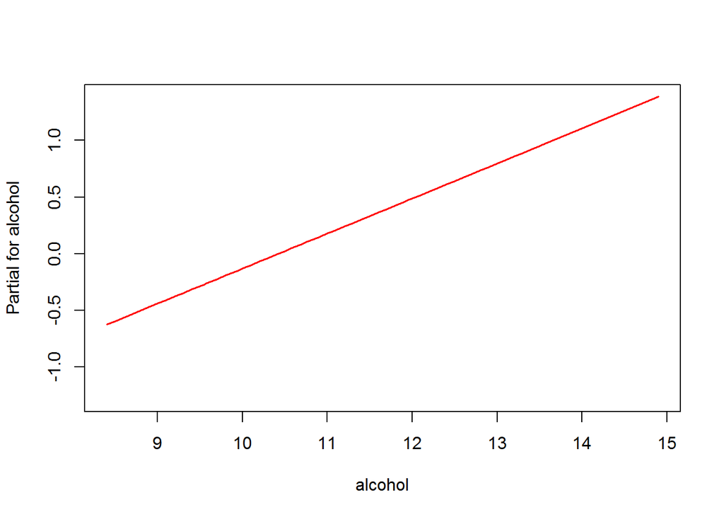

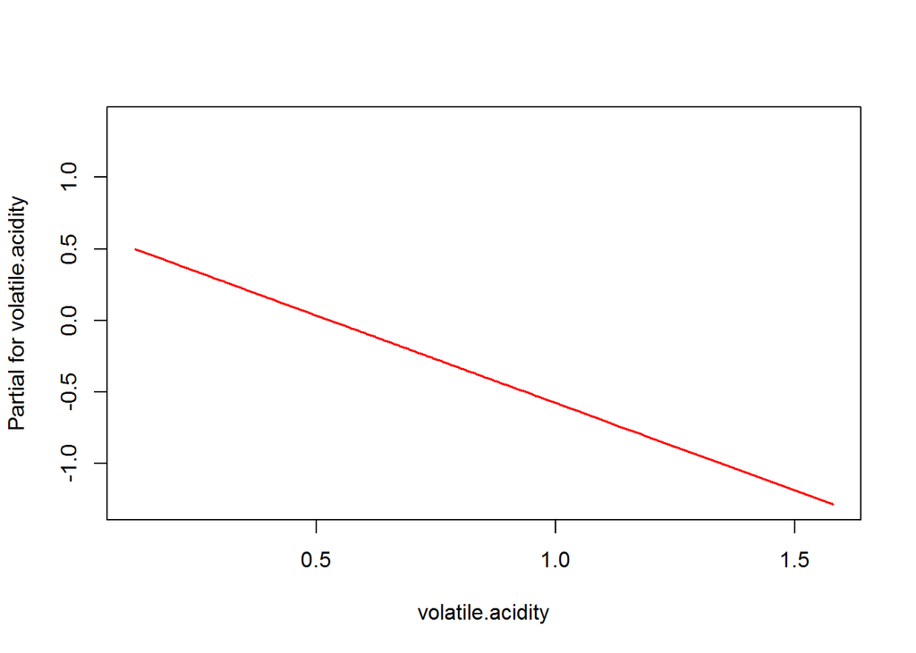

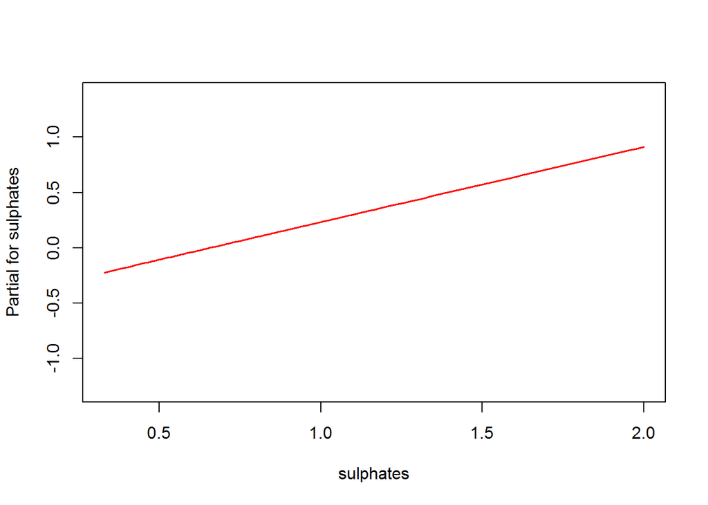

- alcohol - There is a positive correlation between alcohol and quality, partial increases as alcohol percentage increases.
- volatile acidity - There is a negative correlation between quality and volatile.acidity, partial decreases as the volatile acidity increase.
- sulphates - There is a positive correlation between sulphates and quality, partial increases as sulphates percentage increases.

Termplot confirms our finding as we expected.

```
##
##  Paired t-test
##
## data:  RedWines$quality and RedWines$alcohol + RedWines$volatile.acidity + RedWines$sulphates
## t = -237.2, df = 1598, p-value < 2.2e-16
## alternative hypothesis: true difference in means is not equal to 0
## 95 percent confidence interval:
##  -6.022 -5.924
## sample estimates:
## mean of the differences
##                  -5.973
```

```
##                    2.5 %  97.5 %
## (Intercept)       2.2270  2.9947
## alcohol           0.2782  0.3402
## volatile.acidity -1.4117 -1.0311
## sulphates         0.4813  0.8767
```

```
##
## Call:
## lm(formula = quality ~ alcohol + volatile.acidity + sulphates,
##     data = RedWines)
##
## Residuals:
##     Min      1Q  Median      3Q     Max
## -2.7186 -0.3820 -0.0641  0.4745  2.1807
##
## Coefficients:
##                  Estimate Std. Error t value Pr(>|t|)
## (Intercept)        2.6108     0.1957   13.34  < 2e-16 ***
## alcohol            0.3092     0.0158   19.57  < 2e-16 ***
## volatile.acidity  -1.2214     0.0970  -12.59  < 2e-16 ***
## sulphates          0.6790     0.1008    6.74  2.3e-11 ***
## ---
## Signif. codes:  0 '***' 0.001 '**' 0.01 '*' 0.05 '.' 0.1 ' ' 1
##
## Residual standard error: 0.659 on 1595 degrees of freedom
## Multiple R-squared:  0.336,  Adjusted R-squared:  0.335
## F-statistic:  269 on 3 and 1595 DF,  p-value: <2e-16
```

- Pretty much confirms provide numerical presentation of our findings.

```
##      volatile.acidity citric.acid sulphates alcohol quality
## 124             0.710        0.00      0.53     9.5       5
## 104             0.575        0.22      0.51     9.2       5
## 663             0.570        0.06      0.70     9.6       6
## 1364            0.830        0.27      0.48     9.8       4
## 384             0.260        0.42      0.80     9.4       6
## 1288            0.600        0.08      0.37    13.0       5
## 604             0.460        0.52      0.56     9.0       6
## 172             0.420        0.17      0.61     9.2       6
## 853             0.420        0.32      1.07     9.7       5
## 746             0.510        0.18      0.73     9.5       6
```

```
##      fit lwr upr
## 124    5   4   6
## 104    5   4   6
## 663    5   4   7
## 1364   5   4   6
## 384    6   4   7
## 1288   6   5   7
## 604    5   4   7
## 172    5   4   7
## 853    6   5   7
## 746    5   4   7
```

Here I used random sample of 10 rows from original dataset and try to use my model to predict the outcome. Although not 100% accurate, it does validate that our selection of variables. Truely, there is more to wine rating than using couple of varibales to predict the rating.

# Multivariate Analysis

### Talk about some of the relationships you observed in this part of the investigation. Were there features that strengthened each other in terms of looking at your feature(s) of interest?

The most interesting plot in order to see the strengthening of features, was the one including the 2 highest correlation coefficient: Alcohol and Volatile Acidity. Since sulphates and citric acid because their strong relationship with volatile.acidity is likely to reduce the effectiveness of my model, I removed citric acid from the model. I kept sulphates since P value indicated it was significant.

### Were there any interesting or surprising interactions between features?

The most interesting interactions between features was that as volatile.acidity decreases, alcohol content increases, and this makes a better wine.

### OPTIONAL: Did you create any models with your dataset? Discuss the strengths and limitations of your model.

I made a model that uses the volatile acidity, alcohol, and sulphates content of wine to predict its quality. This not perfect model but could be used as guideline to expand on for future modelling and prediction.

# Final Plots and Summary

### Plot One

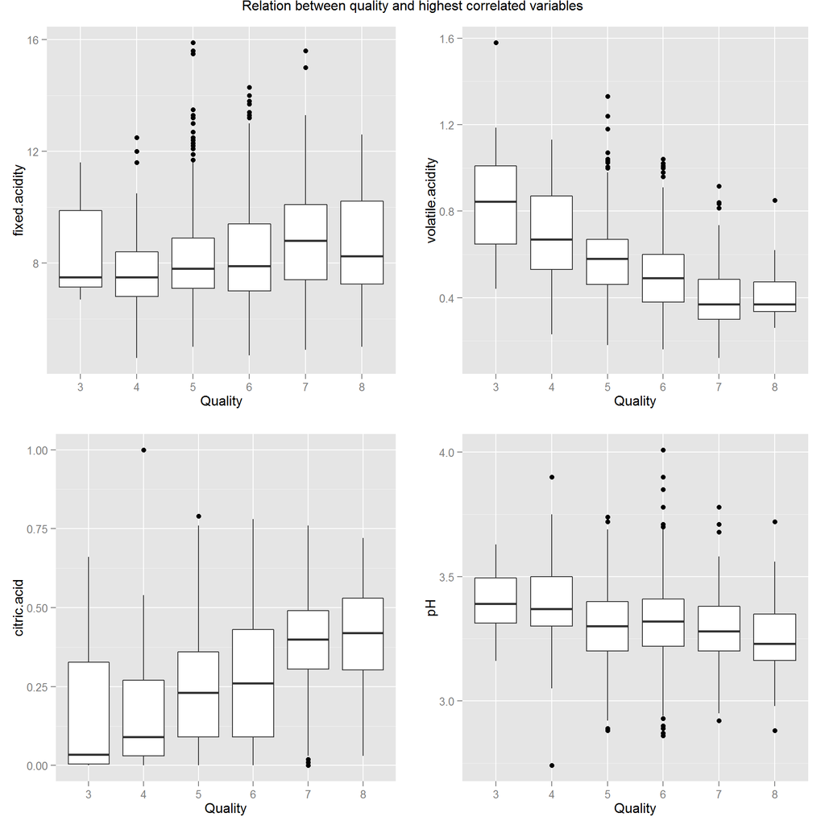

### Description One

- The mean values of fixed.acidity tend to increase as the quality goes up. The best wines come in over 8 while the worst wines did not even reach about 8. Loosely speaking, higher fixed.acidity content correlated with higher wine quality.
- The mean values of volatile.acidity tend to decrease as the quality goes up. The best wines come in at about .4 while the worst wines reach about .8. This is opposite to what we just discovered about fixed.acidity above.
- The mean values of citric acid tend to increase as the quality goes up. The best wines come in over 0.375 while the worst wines are lower than 0.125. Citric acidity had a high correlation with wine quality.
- The mean values of pH tend to decrease as the quality goes up. The best wines is less than 3.25 while the worst wines always higher than 3.25. From pH graph 3 different clusters trending (3 & 4, 5 & 6, 7 & 8) can be oberved.

### Plot Two

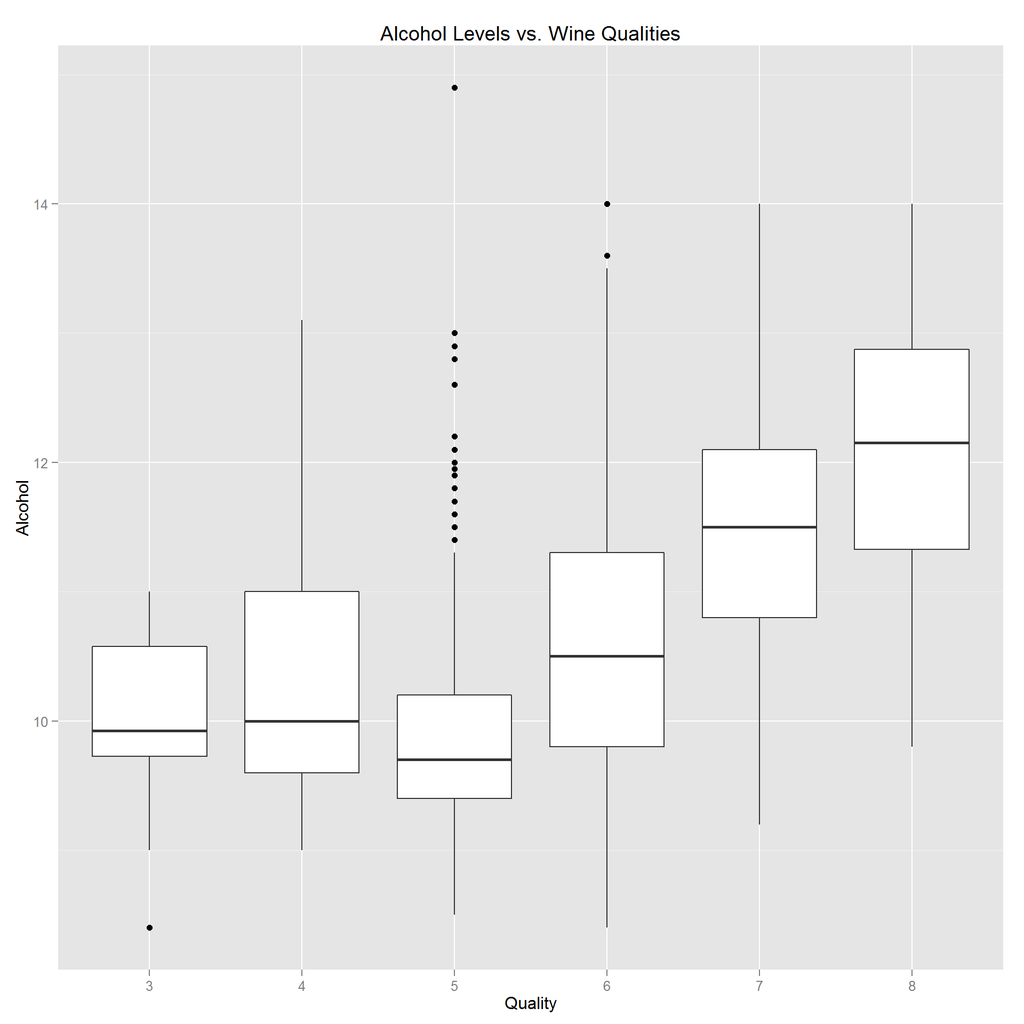

### Description Two

- The above graph demonstrates the effect of alcohol content on wine quality. The mean values alcohol percentage in relation to quality increase as the quality goes up. The worst wines average about 10% alcohol while the best average just above 12% alcohol. The only deviation from this trend is wines rated a 5 which tend to be lower than expected coming in around 9.7% alcohol. loosely speaking, higher alcohol content correlated with higher wine quality.
- There are some outliers and intervals that points that alchol content alone did not produce a higher quality.

### Plot Three

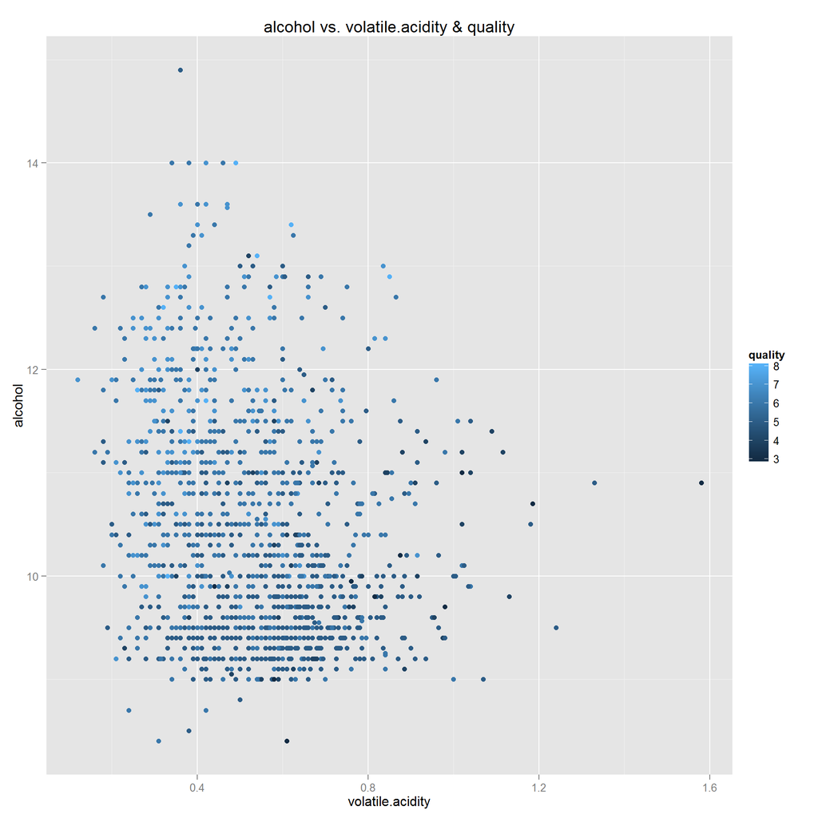

### Description Three

This is improtant if not the important graph. As the correlation tests showed, wine quality was affected most strongly by alcohol and volaticle acidity. A combination of high alcohol content and low volatile acidity produced better wines. This gives me a general sense that a wine with higher alcohol and lower volatile acidity will be rated higher.

# Reflection

This exercise of expolratory Data Analysis brought out many interesting relationships and some surprises when determining the quality of a wine. I was able to identify the key factors that determine and drive wine quality, mainly: alcohol content, sulphates, and acidity. There is more to wine quality than these variables. Nevertheless, it is interesting to realize that I can still judge a wine quality (within resonable bounadries) with very technical variables. The dataset lack some important facors like aging, region etc. I think with larger dataset, better model can be developed to determien wine quality. In spite of that, graphs showed what made or contributed to good or average wine quality.

# References

Business Insider: http://www.businessinsider.com/recognize-high-quality-wine-2014-6#ixzz3d47DJkov

Project pase: http://projectpaso.com/wine-red-blend.html

Part 3: Barry Smith - Questions of taste: http://www.wineanorak.com/philosophy_of_wine3.htm

Cheap Wine vs. Expensive Wine: Can You Really Tell The Difference?: http://www.huffingtonpost.com/2013/01/11/cheap-wine-vs-expensive-wine_n_2457984.html

Is There Really A Taste Difference Between Cheap and Expensive Wines?: http://www.forbes.com/sites/katiebell/2012/07/09/is-there-really-a-taste-difference-between-cheap-and-expensive-wines/

Making Wine: Sulfur Dioxide: http://www.diwinetaste.com/dwt/en2006116.php

Statistical tools for high-throughput data analysis: http://www.sthda.com/english/wiki/visualize-correlation-matrix-using-correlogram

Quick-R: http://www.statmethods.net/stats/

Meta-analysis: https://en.wikipedia.org/wiki/Meta-analysis